# Regresión polinómica

Paul Esker

## Antecedentes

Para muchos de nuestros ensayos, por ejemplo, la cantidad de nitrógeno y el rendimiento, sabemos que la relación no sería lineal sino se representará una forma no lineal. Uno de los ejemplos más comúnes es el de la regresión cuadrática en donde la variable dependiente se incrementará hasta un punto en el proceso, es decir por ejemplo que el rendimiento se sube hasta alguna concentración de la variable independiente, y de ahí la variable dependiente se reducirá debido a un efecto negativo, entre otros factores. Típicamente y desde el punto de vista de agronomía se puede interpretar esta relación de tal manera: “echar” más materia primera (nitrogeno, etc.) no ayuda mejor la productivdad del cultivo en estudio.

La forma general pensar en este tipo de relación: se ajuste una relación entre la variable indendiente, $x$, y la respuesta esperada, $E(y|x)$.

Muy important con este tipo de análisis es tener presente que depende del tipo de “software” hay que verificar como se hace dicho análisis porque se sabe que hay una colinealidad entre las variables, por ejemplo el valor de $X$ y de $X^2$. En este ejemplo vamos a ver este asunto y los métodos para superarlo.

```r
library(tidyverse)
library(Hmisc)
```

```r
library(corrplot)
library(readr)
library(HH)
library(car)
```

## Datos

En este ejemplo lo que tenemos es la siguiente información:

- Densidad = densidad de siembra (número de plantas por $m^2$)
- Rendimiento = cantidad de biomasa

```r
densidad <- rep(c(10,20,30,40,50), each=3)
rendimiento <- c(12.2, 11.4, 12.4, 16, 15.5, 16.5, 18.6, 20.2, 18.2, 17.6, 19.3, 17.1, 18, 16.4, 16.6)

densidades <- data.frame(densidad, rendimiento)
```

## Regresión lineal

Al principio vamos a realizar una regresión lineal para ver lo de la relación y si el modelo se ajuste bien a la relación observada.

```r
modelo1 <- lm(rendimiento~densidad)
anova(modelo1)
```

|  | Df | Sum Sq | Mean Sq | F value | Pr(>F) |
| --- | --- | --- | --- | --- | --- |
| densidad | 1 | 43.20 | 43.200000 | 10.82498 | 0.005857869 |
| Residuals | 13 | 51.88 | 3.990769 | NA | NA |

```r
summary(modelo1)
```

```
##
## Call:
## lm(formula = rendimiento ~ densidad)
##
## Residuals:
##    Min     1Q Median     3Q    Max
##   -2.6   -1.7    0.0    1.5    3.8
##
## Coefficients:
##             Estimate Std. Error t value Pr(>|t|)
## (Intercept) 12.80000    1.20966   10.58  9.3e-08 ***
## densidad     0.12000    0.03647    3.29  0.00586 **
## ---
## Signif. codes:  0 '***' 0.001 '**' 0.01 '*' 0.05 '.' 0.1 ' ' 1
##
## Residual standard error: 1.998 on 13 degrees of freedom
## Multiple R-squared:  0.4544, Adjusted R-squared:  0.4124
## F-statistic: 10.82 on 1 and 13 DF,  p-value: 0.005858
```

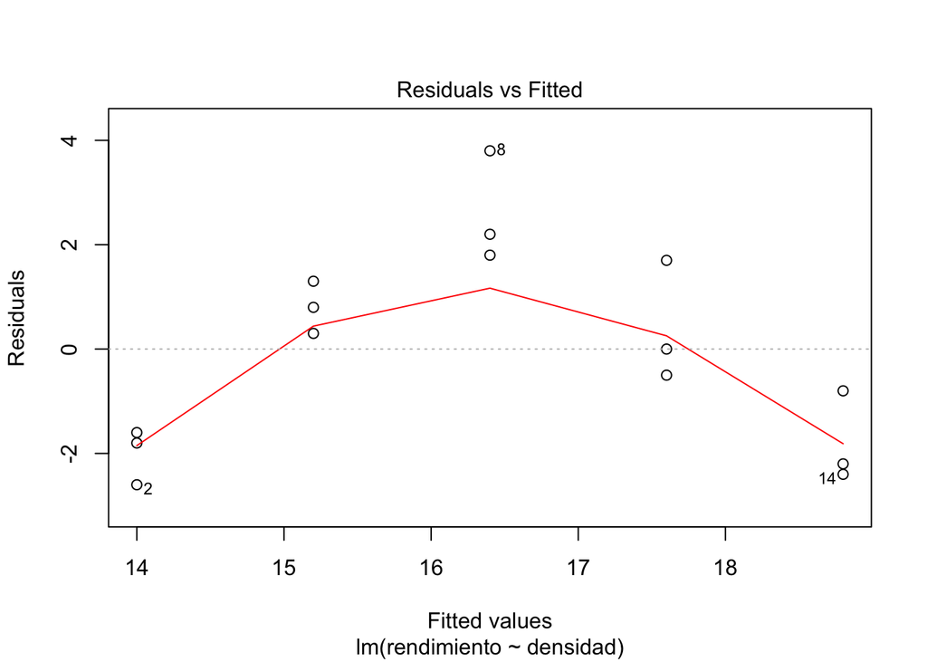

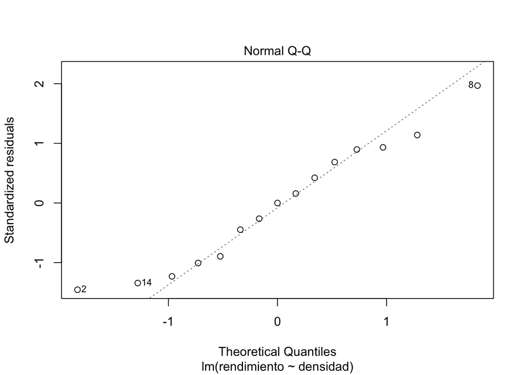

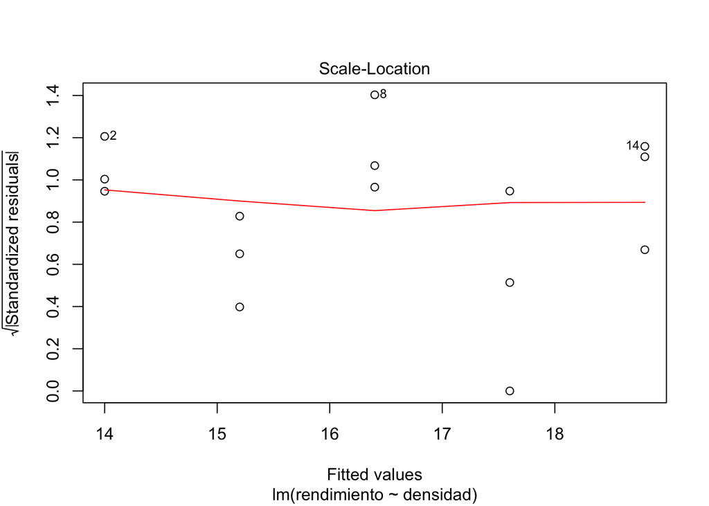

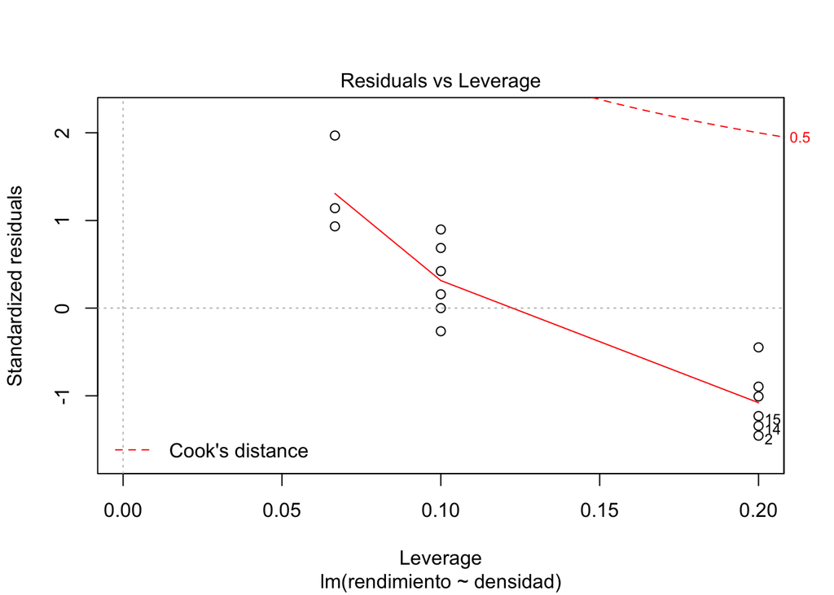

```r
plot(modelo1) # Se puede apreciar que el modelo no se ajuste bien
```

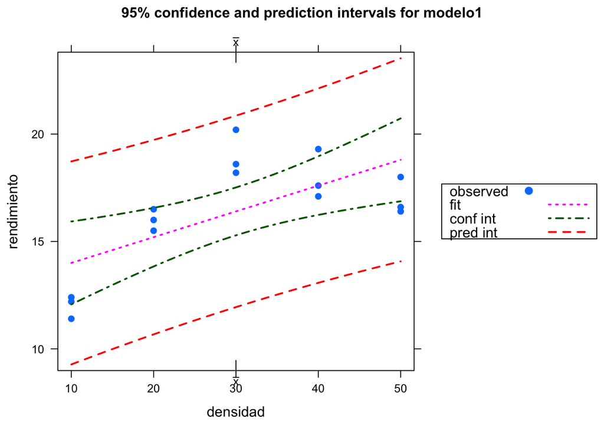

```r
ci.plot(modelo1) # Debería ser obvio que la línea de tendenica no se refleja la medición muy bien; la función es para graficar una relación lineal
```

## Regresión cuadrática 1

Ahora vamos a realizar una regresión cuadrática. Para este ejemplo vamos a ejecutar el mismo análisis ya hecho pero considerando la variable de *densidad* de manera de $densidad$ + $densidad^2$.

```r
# Primero definir la densidad^2
densidad2<-densidad^2

modelo2<-lm(rendimiento~densidad + densidad2)

# Significado
anova(modelo2)
```

|  | Df | Sum Sq | Mean Sq | F value | Pr(>F) |
| --- | --- | --- | --- | --- | --- |
| densidad | 1 | 43.20 | 43.2000000 | 52.46964 | 1.023598e-05 |
| densidad2 | 1 | 42.00 | 42.0000000 | 51.01215 | 1.176731e-05 |
| Residuals | 12 | 9.88 | 0.8233333 | NA | NA |

```r
summary(modelo2)
```

```
##
## Call:
## lm(formula = rendimiento ~ densidad + densidad2)
##
## Residuals:
##    Min     1Q Median     3Q    Max
##  -1.50  -0.50  -0.20   0.35   1.80
##
## Coefficients:
##             Estimate Std. Error t value Pr(>|t|)
## (Intercept)  5.80000    1.12359   5.162 0.000236 ***
## densidad     0.72000    0.08563   8.409 2.25e-06 ***
## densidad2   -0.01000    0.00140  -7.142 1.18e-05 ***
## ---
## Signif. codes:  0 '***' 0.001 '**' 0.01 '*' 0.05 '.' 0.1 ' ' 1
##
## Residual standard error: 0.9074 on 12 degrees of freedom
## Multiple R-squared:  0.8961, Adjusted R-squared:  0.8788
## F-statistic: 51.74 on 2 and 12 DF,  p-value: 1.259e-06
```

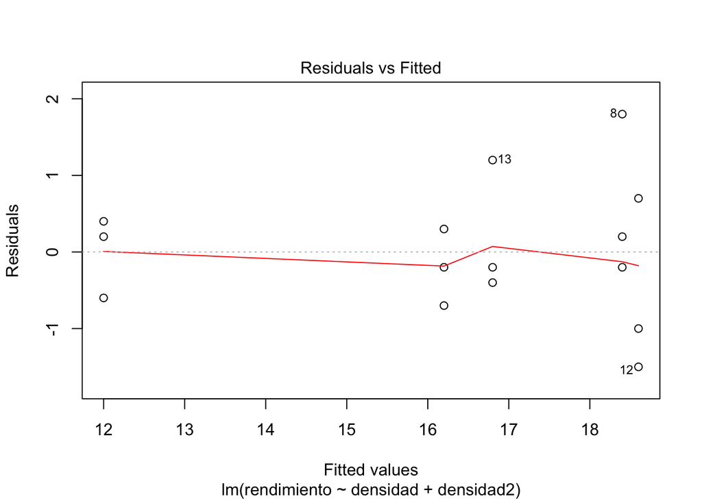

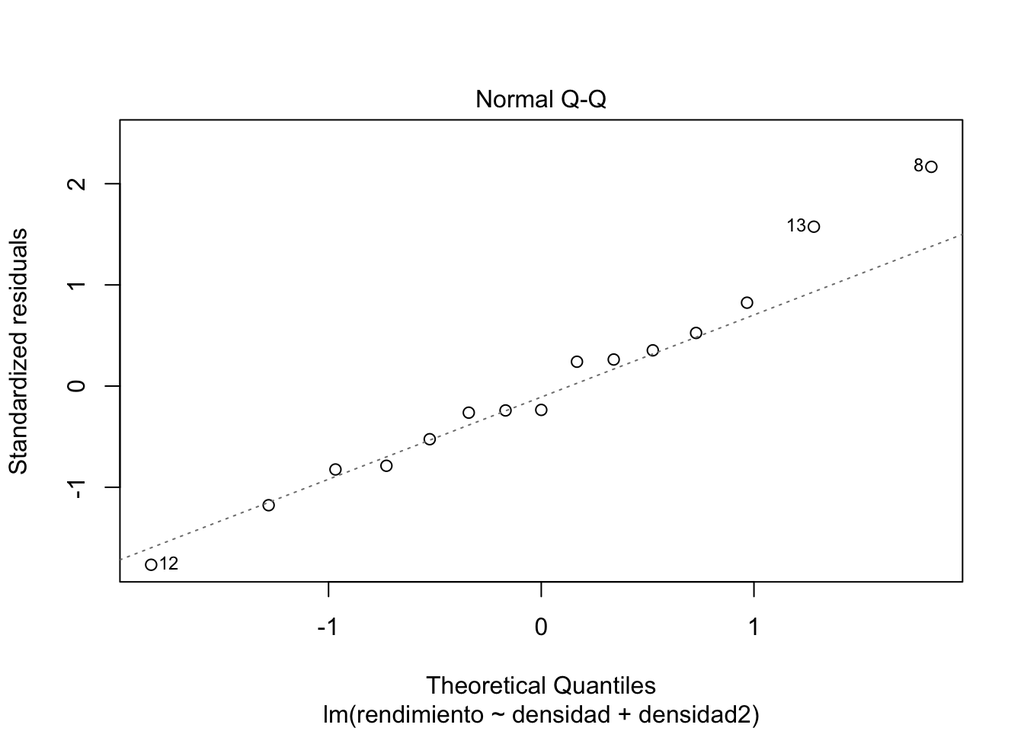

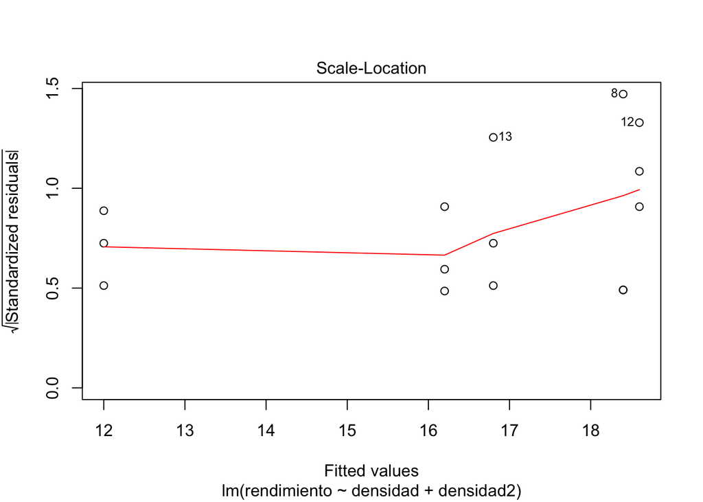

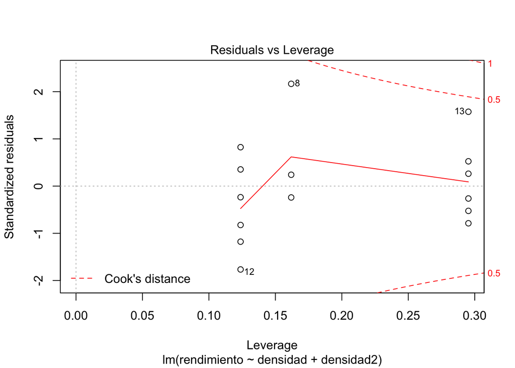

```r
# Supuestos
plot(modelo2)
```